# Revised Statistical Analysis: Absorption

```r
summary(piece_group_x_qomM)
```

```
## Linear mixed model fit by REML ['lmerMod']
## Formula: Absorption ~ 1 + piece + group * mQoM + (1 + mQoM | Pt_ID)
##    Data: data_u_extreme
##
## REML criterion at convergence: 811.8
##
## Scaled residuals:
##      Min       1Q   Median       3Q      Max
## -3.08370 -0.52825  0.08859  0.62629  1.92161
##
## Random effects:
##  Groups   Name        Variance Std.Dev. Corr
##  Pt_ID    (Intercept) 0.6655   0.8158
##           mQoM        0.2409   0.4908   -1.00
##  Residual             0.6319   0.7949
## Number of obs: 287, groups:  Pt_ID, 111
##
## Fixed effects:
##                   Estimate Std. Error t value
## (Intercept)        3.71485    0.24450  15.194
## pieceSchnittke    -0.08769    0.11631  -0.754
## pieceFolk          0.14576    0.13469   1.082
## groupVirtual       0.44298    0.43734   1.013
## mQoM               4.71874    2.35831   2.001
## groupVirtual:mQoM -8.09914    3.16002  -2.563
##
## Correlation of Fixed Effects:
##             (Intr) pcSchn picFlk grpVrt mQoM
## piecSchnttk -0.149
## pieceFolk    0.227  0.453
## groupVirtul -0.556 -0.046 -0.229
## mQoM        -0.874 -0.091 -0.491  0.525
## grpVrtl:mQM  0.639  0.088  0.347 -0.862 -0.733
```

check model parameter estimates to understand the interaction between group and motion on absorption

```
## Package 'merDeriv' needs to be installed to compute confidence intervals
##   for random effect parameters.
```

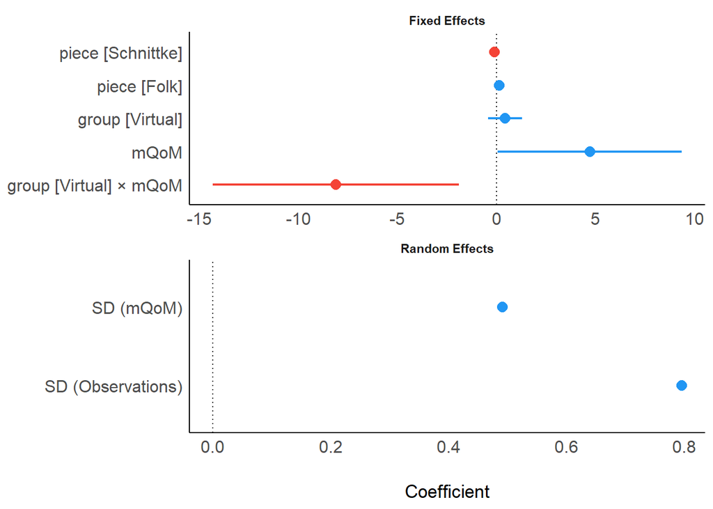

```r
#library(ggplot2)
library(see)
library(parameters)
plot(model_parameters(piece_group_x_qomM))
```

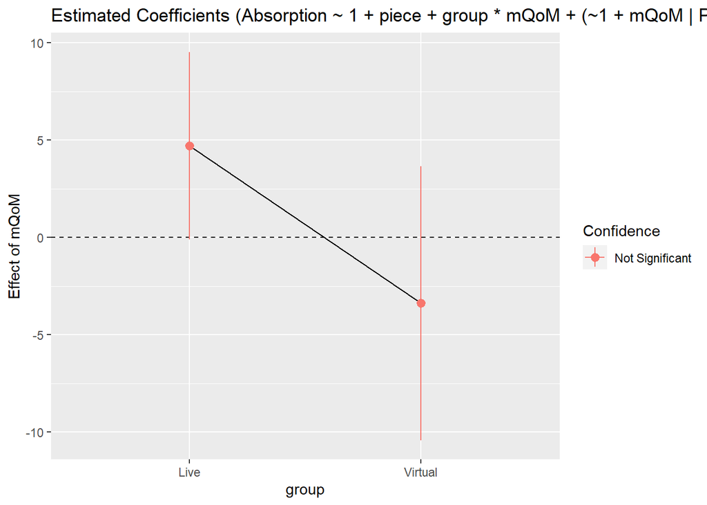

```r
library(modelbased)
slopes<-estimate_slopes(piece_group_x_qomM, trend = "mQoM", at = "group")

plot(slopes)
```

```r
slopes
```

```
## Estimated Marginal Effects
##
## group   | Coefficient |   SE |         95% CI |     t |     df |     p
## ----------------------------------------------------------------------
## Live    |        4.72 | 2.43 | [ -0.09, 9.53] |  1.94 | 123.27 | 0.054
## Virtual |       -3.38 | 2.77 | [-10.41, 3.65] | -1.22 |   5.23 | 0.275
## Marginal effects estimated for mQoM
```

```r
estimate_contrasts(piece_group_x_qomM, at = "mQoM", contrast = "group")
```

```
## Marginal Contrasts Analysis
##
## Level1 |  Level2 | mQoM | Difference |        95% CI |   SE |     df |     t |     p
## ------------------------------------------------------------------------------------
## Live   | Virtual | 0.02 |      -0.31 | [-1.21, 0.58] | 0.44 |  36.14 | -0.71 | 0.483
## Live   | Virtual | 0.05 |  -8.14e-03 | [-0.68, 0.66] | 0.33 |  52.82 | -0.02 | 0.981
## Live   | Virtual | 0.09 |       0.30 | [-0.20, 0.79] | 0.25 | 101.00 |  1.18 | 0.242
## Live   | Virtual | 0.13 |       0.60 | [ 0.15, 1.05] | 0.23 | 107.15 |  2.64 | 0.009
## Live   | Virtual | 0.17 |       0.90 | [ 0.35, 1.45] | 0.28 |  57.25 |  3.29 | 0.002
## Live   | Virtual | 0.20 |       1.21 | [ 0.46, 1.95] | 0.37 |  36.72 |  3.28 | 0.002
## Live   | Virtual | 0.24 |       1.51 | [ 0.53, 2.50] | 0.48 |  29.56 |  3.14 | 0.004
## Live   | Virtual | 0.28 |       1.82 | [ 0.58, 3.05] | 0.60 |  26.53 |  3.01 | 0.006
## Live   | Virtual | 0.32 |       2.12 | [ 0.62, 3.62] | 0.73 |  25.00 |  2.91 | 0.008
## Live   | Virtual | 0.35 |       2.42 | [ 0.66, 4.19] | 0.86 |  24.14 |  2.83 | 0.009
##
## Marginal contrasts estimated at group
## p-value adjustment method: Holm (1979)
```

#### Refit with REML to report those variance estimates

From: https://gkhajduk.github.io/2017-03-09-mixed-models/

“Notice that we have fitted our models with REML = FALSE.

REML stands for restricted (or “residual”) maximum likelihood and it is the default parameter estimation criterion for linear mixed models. As you probably guessed, ML stands for maximum likelihood - you can set REML = FALSE in your call to lmer to use ML estimates. However, ML estimates are known to be bias and with REML being usually less bias, REML estimates of variance components are generally preferred. This is why in our previous models we skipped setting REML - we just left it as default (i.e. REML = TRUE).

REML assumes that fixed effects structure is correct. You should use maximum likelihood when comparing models with different fixed effects, as ML doesn’t rely on the coefficients of the fixed effects - and that’s why we are refitting our full and reduced models above with the addition of REML = FALSE in the call.

Even though you use ML to compare models you should **report parameter estimates from your final “best” REML model**, as ML may underestimate variance of the random effects.”

```r
piece_group_x_qomM<-lmer(Absorption ~ 1 + piece + group*mQoM + (1+mQoM|Pt_ID), data = data_u_extreme, REML = FALSE)
summary(piece_group_x_qomM)
```

```
## Linear mixed model fit by maximum likelihood  ['lmerMod']
## Formula: Absorption ~ 1 + piece + group * mQoM + (1 + mQoM | Pt_ID)
##    Data: data_u_extreme
##
##      AIC      BIC   logLik deviance df.resid
##    829.1    865.7   -404.6    809.1      277
##
## Scaled residuals:
##      Min       1Q   Median       3Q      Max
## -3.11322 -0.53516  0.08616  0.63099  1.96581
##
## Random effects:
##  Groups   Name        Variance Std.Dev. Corr
##  Pt_ID    (Intercept) 0.6926   0.8322
##           mQoM        0.5482   0.7404   -1.00
##  Residual             0.6201   0.7875
## Number of obs: 287, groups:  Pt_ID, 111
##
## Fixed effects:
##                   Estimate Std. Error t value
## (Intercept)         3.7081     0.2421  15.316
## pieceSchnittke     -0.0894     0.1152  -0.776
## pieceFolk           0.1442     0.1332   1.082
## groupVirtual        0.4516     0.4332   1.043
## mQoM                4.7956     2.3197   2.067
## groupVirtual:mQoM  -8.1896     3.1032  -2.639
##
## Correlation of Fixed Effects:
##             (Intr) pcSchn picFlk grpVrt mQoM
## piecSchnttk -0.149
## pieceFolk    0.223  0.453
## groupVirtul -0.556 -0.046 -0.228
## mQoM        -0.874 -0.091 -0.489  0.526
## grpVrtl:mQM  0.641  0.088  0.348 -0.863 -0.735
```

```r
## Refit with REML
piece_group_x_qomM_reml<-lmer(Absorption ~ 1 + piece + group*mQoM + (1+mQoM|Pt_ID), data = data_u_extreme, REML = TRUE)
summary(piece_group_x_qomM_reml)
```

```
## Linear mixed model fit by REML ['lmerMod']
## Formula: Absorption ~ 1 + piece + group * mQoM + (1 + mQoM | Pt_ID)
##    Data: data_u_extreme
##
## REML criterion at convergence: 811.8
##
## Scaled residuals:
##      Min       1Q   Median       3Q      Max
## -3.08370 -0.52825  0.08859  0.62629  1.92161
##
## Random effects:
##  Groups   Name        Variance Std.Dev. Corr
##  Pt_ID    (Intercept) 0.6655   0.8158
##           mQoM        0.2409   0.4908   -1.00
##  Residual             0.6319   0.7949
## Number of obs: 287, groups:  Pt_ID, 111
##
## Fixed effects:
##                   Estimate Std. Error t value
## (Intercept)        3.71485    0.24450  15.194
## pieceSchnittke    -0.08769    0.11631  -0.754
## pieceFolk          0.14576    0.13469   1.082
## groupVirtual       0.44298    0.43734   1.013
## mQoM               4.71874    2.35831   2.001
## groupVirtual:mQoM -8.09914    3.16002  -2.563
##
## Correlation of Fixed Effects:
##             (Intr) pcSchn picFlk grpVrt mQoM
## piecSchnttk -0.149
## pieceFolk    0.227  0.453
## groupVirtul -0.556 -0.046 -0.229
## mQoM        -0.874 -0.091 -0.491  0.525
## grpVrtl:mQM  0.639  0.088  0.347 -0.862 -0.733
```

```r
## fitting with data or df.wide (contains lots of NAs) produce the same results.
piece_group_x_qomM<-lmer(Absorption ~ 1 + piece + group*mQoM + (1+mQoM|Pt_ID), data = data, REML = FALSE)
summary(piece_group_x_qomM)
```

```
## Linear mixed model fit by maximum likelihood  ['lmerMod']
## Formula: Absorption ~ 1 + piece + group * mQoM + (1 + mQoM | Pt_ID)
##    Data: data
##
##      AIC      BIC   logLik deviance df.resid
##    852.1    888.9   -416.1    832.1      283
##
## Scaled residuals:
##      Min       1Q   Median       3Q      Max
## -3.11763 -0.49103  0.07284  0.64688  1.90812
##
## Random effects:
##  Groups   Name        Variance Std.Dev. Corr
##  Pt_ID    (Intercept) 0.4814   0.6938
##           mQoM        6.0538   2.4604   0.08
##  Residual             0.6188   0.7866
## Number of obs: 293, groups:  Pt_ID, 111
##
## Fixed effects:
##                   Estimate Std. Error t value
## (Intercept)         3.9668     0.2095  18.937
## pieceSchnittke     -0.0595     0.1143  -0.520
## pieceFolk           0.2044     0.1303   1.568
## groupVirtual       -0.1076     0.3665  -0.294
## mQoM                1.8402     2.0048   0.918
## groupVirtual:mQoM  -2.9938     2.6315  -1.138
##
## Correlation of Fixed Effects:
##             (Intr) pcSchn picFlk grpVrt mQoM
## piecSchnttk -0.199
## pieceFolk    0.164  0.450
## groupVirtul -0.557 -0.044 -0.217
## mQoM        -0.833 -0.073 -0.464  0.516
## grpVrtl:mQM  0.620  0.084  0.336 -0.800 -0.748
```

```r
piece_group_x_qomM<-lmer(Absorption ~ 1 + piece + group*mQoM + (1+mQoM|Pt_ID), data = df.wide, REML = FALSE)
summary(piece_group_x_qomM)
```

```
## Linear mixed model fit by maximum likelihood  ['lmerMod']
## Formula: Absorption ~ 1 + piece + group * mQoM + (1 + mQoM | Pt_ID)
##    Data: df.wide
##
##      AIC      BIC   logLik deviance df.resid
##    852.1    888.9   -416.1    832.1      283
##
## Scaled residuals:
##      Min       1Q   Median       3Q      Max
## -3.11763 -0.49103  0.07284  0.64688  1.90812
##
## Random effects:
##  Groups   Name        Variance Std.Dev. Corr
##  Pt_ID    (Intercept) 0.4814   0.6938
##           mQoM        6.0538   2.4604   0.08
##  Residual             0.6188   0.7866
## Number of obs: 293, groups:  Pt_ID, 111
##
## Fixed effects:
##                   Estimate Std. Error t value
## (Intercept)         3.9668     0.2095  18.937
## pieceSchnittke     -0.0595     0.1143  -0.520
## pieceFolk           0.2044     0.1303   1.568
## groupVirtual       -0.1076     0.3665  -0.294
## mQoM                1.8402     2.0048   0.918
## groupVirtual:mQoM  -2.9938     2.6315  -1.138
##
## Correlation of Fixed Effects:
##             (Intr) pcSchn picFlk grpVrt mQoM
## piecSchnttk -0.199
## pieceFolk    0.164  0.450
## groupVirtul -0.557 -0.044 -0.217
## mQoM        -0.833 -0.073 -0.464  0.516
## grpVrtl:mQM  0.620  0.084  0.336 -0.800 -0.748
```

#### Check model assumptions

Here is a tutorial that was recommended: https://bodowinter.com/tutorial/bw_LME_tutorial1.pdf https://bodowinter.com/tutorial/bw_LME_tutorial2.pdf

*Linearity* Because there is no obvious pattern in the residuals, it seems like there is no violation of the linearity assumption.

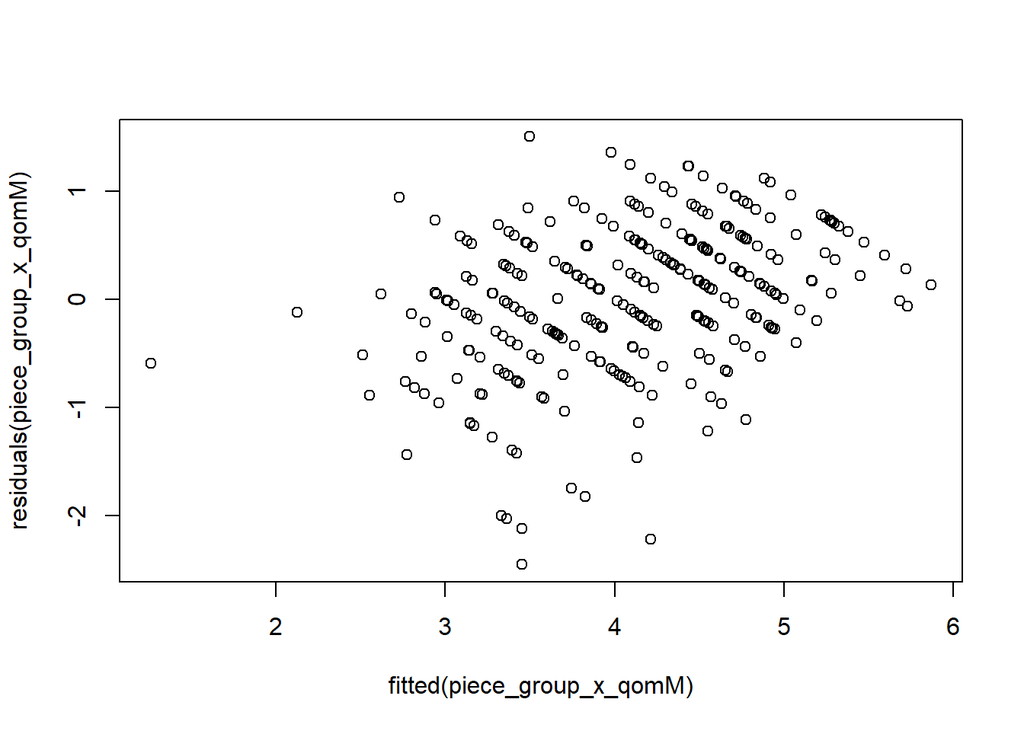

```r
plot(fitted(piece_group_x_qomM),residuals(piece_group_x_qomM))
```

*Absence of Collinearity* If two fixed effects predictors are correlated with each other, they are said to be collinear.

*Homoskedasticity* This doesn’t appear obviously heteroscedastic but it isn’t perfect either. We can check with Levene’s test for checking variance across groups

```r
leveneTest(data_u_extreme$Absorption, data_u_extreme$group, center = mean) # variance is not different across groups.
```

```
## Levene's Test for Homogeneity of Variance (center = mean)
##        Df F value Pr(>F)
## group   1  0.0081 0.9283
##       285
```

*Normality of residuals* “The normality of residuals assumption is the one that is least important. Interestingly, many people seem to think it is the most important one, but it turns  
out that linear models are relatively robust against violations of the assumptions of normality. Researchers differ with respect to how much weight they put onto  
checking this assumption. For example, Gellman and Hill (2007), a famous book on linear models and mixed models, do not even recommend diagnostics of the normality assumption (ibid. 46).”

Therefore, it may be ok to violate this assumption.

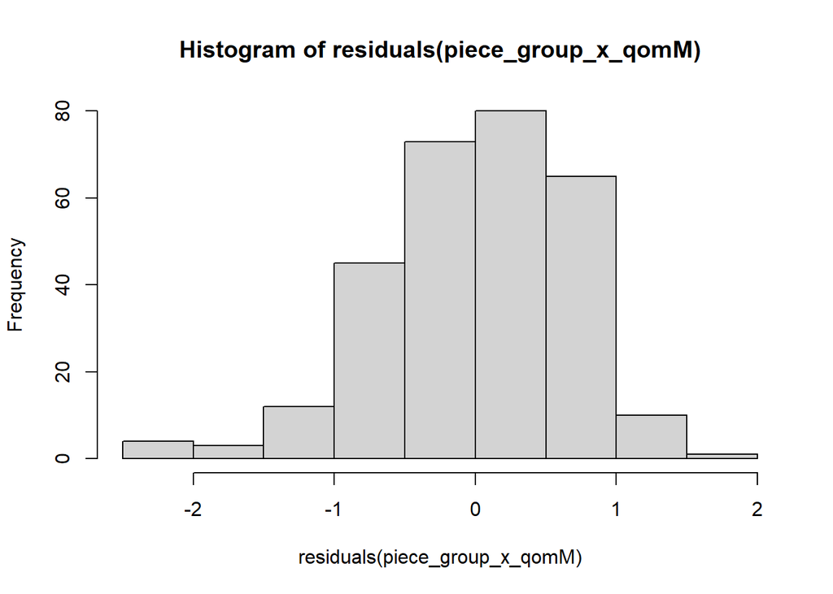

```r
hist(residuals(piece_group_x_qomM)) #  not bad. slight negative tail.
```

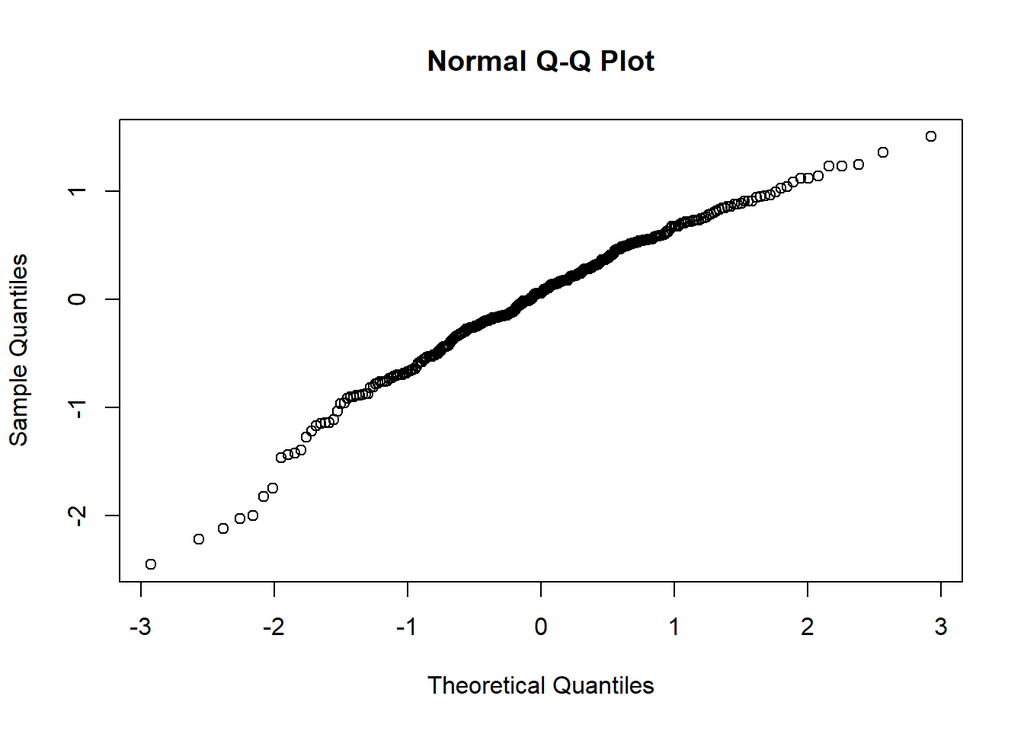

```r
qqnorm(residuals(piece_group_x_qomM)) # slight skew
```

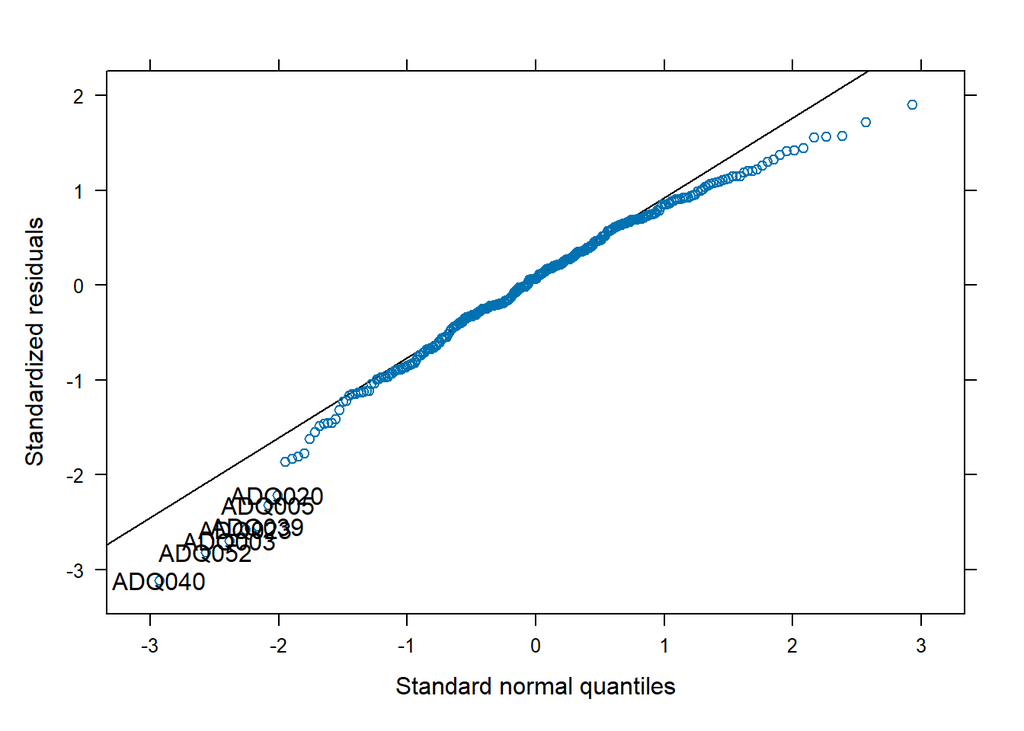

```r
require(lattice)
qqmath(piece_group_x_qomM, id=0.05) #id: identifies values that may be exerting undue influence on the model (i.e. outliers
```

### Visualize

Figure 4 in the manuscript

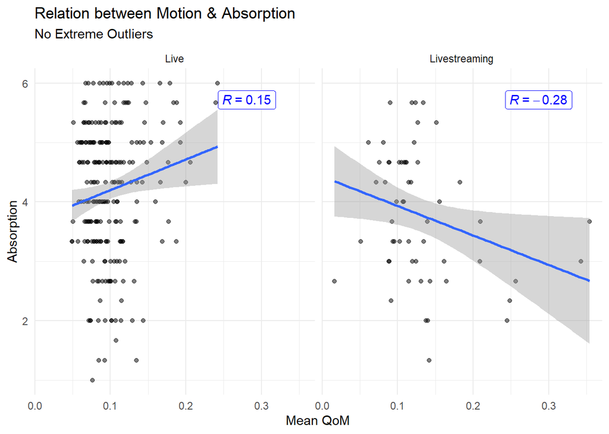

```r
#update group label
data_u_extreme$group<-factor(data_u_extreme$group, levels = c("Live", "Virtual"), labels = c("Live", "Livestreaming"))

title =  "Relation between Motion & Absorption"
subtitle= "No Extreme Outliers"

# r
p<-data_u_extreme%>%
  ggplot(aes(x = mQoM, y = Absorption))+
  geom_point(alpha = .5)+
  labs(title =title,subtitle = subtitle, x = "Mean QoM", y = "Absorption")+
  geom_smooth(method = lm)+
  facet_grid(cols = vars(group))+
  theme_minimal()+
  stat_cor(aes(label = ..r.label..), label.x.npc = .67, color = "blue", geom = "label")#+
  #stat_cor(aes(label = ..rr.label..), label.x.npc = .65, color = "blue", geom = "label")+
  #stat_cor(aes(label = ..rr.label..), label.x.npc = .65, color = "blue", geom = "label")+
  #stat_cor(aes(label = ..r.label..), label.y.npc = .2,label.x.npc = .65, color = "blue", geom = "label")+
  #stat_cor(aes(label = paste(..rr.label.., ..p.label.., sep = "~`,`~")), label.x.npc = .6, color = "blue", geom = "label", size = 2.5)+
  #stat_cor(aes(label = ..r.label..), label.y.npc = .2,label.x.npc = .65, color = "blue", geom = "label", size = 2.5)

p
```

```r
graphname<-paste0("../revised_plots/", title,subtitle, ".png")
ggsave(graphname, width = 15, height = 8, units = 'cm', dpi = 500)
graphname<-paste0("../revised_plots/Publication_Figures/", title,subtitle, ".jpg")
ggsave(graphname, width = 15, height = 8, units = 'cm', dpi = 500, bg = "white")
```

## 3.6.2 LME with Stilling & Absorption

```r
dat<-df.full%>%select(Pt_ID, EC,contains("mus_abs"), contains("Stilling"))%>%select(-Stilling_FullConcert, -Stilling_Bach)

df.long<-dat%>%pivot_longer(!c(EC, Pt_ID), #make long
                            names_to = c("var", "piece"),
                            names_pattern ="(.*)_(.*)",
                            values_to = "response")

df.wide<-df.long%>%pivot_wider(names_from = var, values_from = response)

df.wide$piece<-factor(df.wide$piece, levels = c("Beethoven", "Schnittke", "Bach", "Folk"))
#factor for the correct facet order

df.wide%<>%rename("Absorption" = "mus_abs")

data<-df.wide%>%drop_na() #408 to 233

data%>%group_by(piece)%>%summarise(n())
```

```
## # A tibble: 3 × 2
##   piece     `n()`
##   <fct>     <int>
## 1 Beethoven    80
## 2 Schnittke    77
## 3 Folk         76
```

### Remove extreme outliers

#### Absorption

```r
outliers<-data %>%
  group_by(piece) %>%
  identify_outliers(Absorption)

outliers # 0; None are extreme.
```

```
## [1] piece      Pt_ID      EC         Absorption Stilling   is.outlier is.extreme
## <0 rows> (or 0-length row.names)
```

```r
extreme<-outliers%>%filter(is.extreme == TRUE)

extreme # none are extreme
```

```
## [1] piece      Pt_ID      EC         Absorption Stilling   is.outlier is.extreme
## <0 rows> (or 0-length row.names)
```

```r
# remove specific instances that are outliers (Pt_ID and piece, because lme can handle missing data so you don't need to remove the whole participant)

# data uten outliers
data_u_outliers<-data%>% # 233 to 233 : looks good!
  group_by(piece) %>%
  filter(!is_outlier(Absorption))%>%
  ungroup()

# data uten extreme
data_u_extreme<-data%>% # 233 to 233 : looks good!
  group_by(piece) %>%
  filter(!is_extreme(Absorption))%>%
  ungroup()
```

#### Stilling

```r
data%>%summarize(mean = mean(Stilling))
```

```
## # A tibble: 1 × 1
##    mean
##   <dbl>
## 1 0.547
```

```r
outliers<-data %>%
  group_by(piece) %>%
  identify_outliers(Stilling)

outliers # 3
```

```
## # A tibble: 3 × 7
##   piece Pt_ID     EC Absorption Stilling is.outlier is.extreme
##   <fct> <chr>  <dbl>      <dbl>    <dbl> <lgl>      <lgl>
## 1 Folk  ADQ058  3.29       5       0.154 TRUE       TRUE
## 2 Folk  ADQ029  4.86       6       0.205 TRUE       FALSE
## 3 Folk  ADQ022  5          3.67    0.256 TRUE       FALSE
```

```r
extreme_outliers<- outliers%>%filter(is.extreme == TRUE)

extreme_outliers # 1
```

```
## # A tibble: 1 × 7
##   piece Pt_ID     EC Absorption Stilling is.outlier is.extreme
##   <fct> <chr>  <dbl>      <dbl>    <dbl> <lgl>      <lgl>
## 1 Folk  ADQ058  3.29          5    0.154 TRUE       TRUE
```

```r
data_u_outliers<-data_u_outliers%>% # 233 to 230
  group_by(piece) %>%
  filter(!is_outlier(Stilling))%>%
  ungroup()

data_u_extreme<-data_u_extreme%>% # 233 to 232 : looks good!
  group_by(piece) %>%
  filter(!is_extreme(Stilling))%>%
  ungroup()
```

In the mixed anova we found that piece was a sig predictor of absorption. This was not the case when using lme4. This is probably because there are different sample sizes due to missing data in the stilling and qom measures.

```r
# note that these are without random slopes

baseline<-lmer(Absorption ~ 1 +(1|Pt_ID), data = data_u_extreme, REML = FALSE)
pieceM<-lmer(Absorption ~ 1 + piece + (1|Pt_ID), data = data_u_extreme, REML = FALSE)
anova(baseline, pieceM) # trending
```

```
## Data: data_u_extreme
## Models:
## baseline: Absorption ~ 1 + (1 | Pt_ID)
## pieceM: Absorption ~ 1 + piece + (1 | Pt_ID)
##          npar    AIC    BIC  logLik deviance  Chisq Df Pr(>Chisq)
## baseline    3 675.67 686.01 -334.84   669.67
## pieceM      5 675.06 692.29 -332.53   665.06 4.6117  2    0.09968 .
## ---
## Signif. codes:  0 '***' 0.001 '**' 0.01 '*' 0.05 '.' 0.1 ' ' 1
```

```r
baseline<-lmer(Absorption ~ 1 +(1|Pt_ID), data = data, REML = FALSE)
pieceM<-lmer(Absorption ~ 1 + piece + (1|Pt_ID), data = data, REML = FALSE)
anova(baseline, pieceM) # still only trending
```

```
## Data: data
## Models:
## baseline: Absorption ~ 1 + (1 | Pt_ID)
## pieceM: Absorption ~ 1 + piece + (1 | Pt_ID)
##          npar    AIC    BIC  logLik deviance  Chisq Df Pr(>Chisq)
## baseline    3 678.36 688.72 -336.18   672.36
## pieceM      5 677.33 694.58 -333.66   667.33 5.0352  2    0.08065 .
## ---
## Signif. codes:  0 '***' 0.001 '**' 0.01 '*' 0.05 '.' 0.1 ' ' 1
```

#### Random slope Without extreme

Extreme = < Q1 - 3* IQR or > Q3 + 3* IQR

```r
baseline<-lmer(Absorption ~ 1 +(1+Stilling|Pt_ID), data = data_u_extreme, REML = FALSE)
pieceM<-lmer(Absorption ~ 1 + piece + (1+Stilling|Pt_ID), data = data_u_extreme, REML = FALSE)
stillM<-lmer(Absorption ~ 1 + piece + Stilling + (1+Stilling|Pt_ID), data = data_u_extreme, REML = FALSE) #trending # boundary (singular) fit: see help('isSingular')
```

```
## boundary (singular) fit: see help('isSingular')
```

```r
intxnM<-lmer(Absorption ~ 1 + piece * Stilling + (1+Stilling|Pt_ID), data = data_u_extreme, REML = FALSE)
anova(baseline, pieceM, stillM, intxnM) # trending main effect of stilling
```

```
## Data: data_u_extreme
## Models:
## baseline: Absorption ~ 1 + (1 + Stilling | Pt_ID)
## pieceM: Absorption ~ 1 + piece + (1 + Stilling | Pt_ID)
## stillM: Absorption ~ 1 + piece + Stilling + (1 + Stilling | Pt_ID)
## intxnM: Absorption ~ 1 + piece * Stilling + (1 + Stilling | Pt_ID)
##          npar    AIC    BIC  logLik deviance  Chisq Df Pr(>Chisq)
## baseline    5 679.55 696.78 -334.77   669.55
## pieceM      7 678.97 703.10 -332.48   664.97 4.5777  2     0.1014
## stillM      8 677.94 705.52 -330.97   661.94 3.0248  1     0.0820 .
## intxnM     10 681.30 715.77 -330.65   661.30 0.6409  2     0.7258
## ---
## Signif. codes:  0 '***' 0.001 '**' 0.01 '*' 0.05 '.' 0.1 ' ' 1
```

```r
stillM<-lmer(Absorption ~ 1 + Stilling + (1+Stilling|Pt_ID), data = data_u_extreme, REML = FALSE)
anova(baseline, stillM) # trending p = .06
```

```
## Data: data_u_extreme
## Models:
## baseline: Absorption ~ 1 + (1 + Stilling | Pt_ID)
## stillM: Absorption ~ 1 + Stilling + (1 + Stilling | Pt_ID)
##          npar    AIC    BIC  logLik deviance  Chisq Df Pr(>Chisq)
## baseline    5 679.55 696.78 -334.77   669.55
## stillM      6 678.10 698.79 -333.05   666.10 3.4417  1    0.06357 .
## ---
## Signif. codes:  0 '***' 0.001 '**' 0.01 '*' 0.05 '.' 0.1 ' ' 1
```

Estimate contrasts

```r
estimate_slopes(stillM, trend = "Stilling")
```

```
## Estimated Marginal Effects
##
## Coefficient |   SE |        95% CI | t(38.06) |     p
## -----------------------------------------------------
## 1.39        | 0.79 | [-0.21, 2.99] |     1.76 | 0.087
## Marginal effects estimated for Stilling
```

#### Check model assumptions

Here is a tutorial that was recommended: https://bodowinter.com/tutorial/bw_LME_tutorial1.pdf https://bodowinter.com/tutorial/bw_LME_tutorial2.pdf

*Linearity* Because there is no obvious pattern in the residuals, it seems like there is no violation of the linearity assumption.

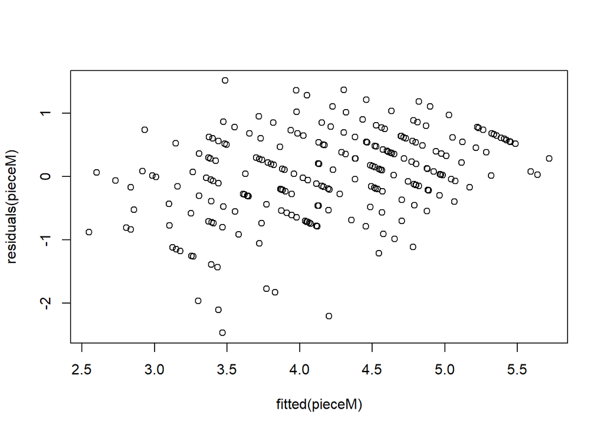

```r
plot(fitted(pieceM),residuals(pieceM))
```

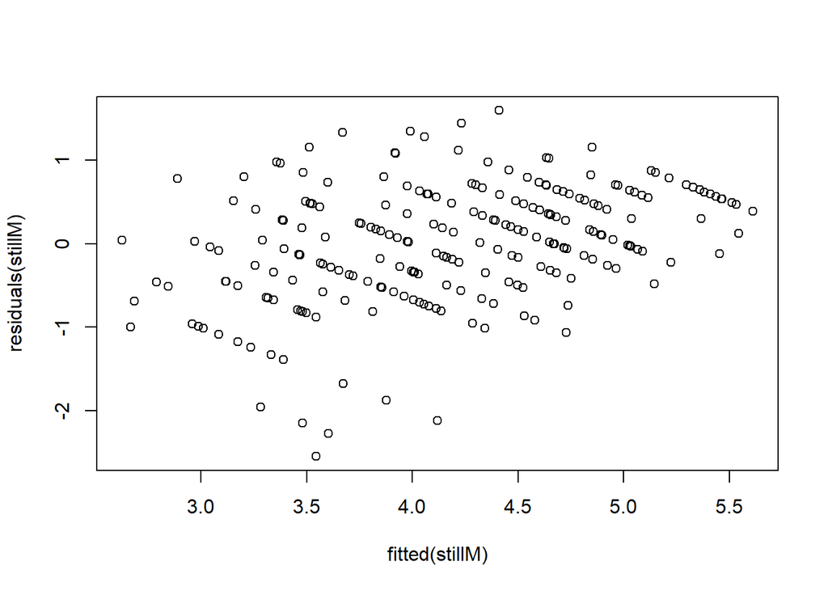

```r
plot(fitted(stillM),residuals(stillM))
```

*Absence of Collinearity* If two fixed effects predictors are correlated with each other, they are said to be collinear.

*Homoskedasticity* This doesn’t appear obviously heteroscedastic but it isn’t perfect either.

*Normality of residuals* “The normality of residuals assumption is the one that is least important. Interestingly, many people seem to think it is the most important one, but it turns  
out that linear models are relatively robust against violations of the assumptions of normality. Researchers differ with respect to how much weight they put onto  
checking this assumption. For example, Gellman and Hill (2007), a famous book on linear models and mixed models, do not even recommend diagnostics of the normality assumption (ibid. 46).”

Therefore, it may be ok to violate this assumption.

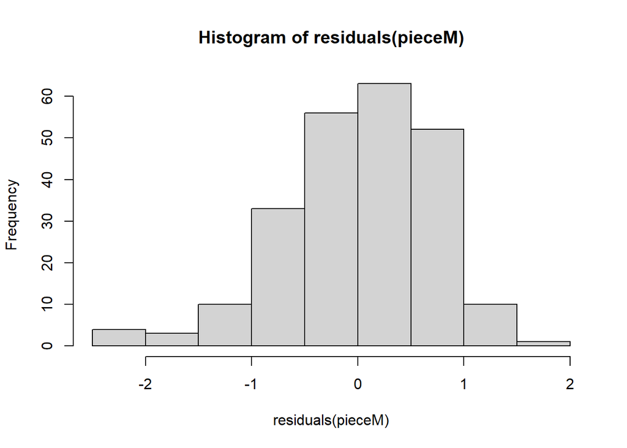

```r
# The histogram looks skewed with a negative tail.
hist(residuals(pieceM)) # still looks slightly skewed
```

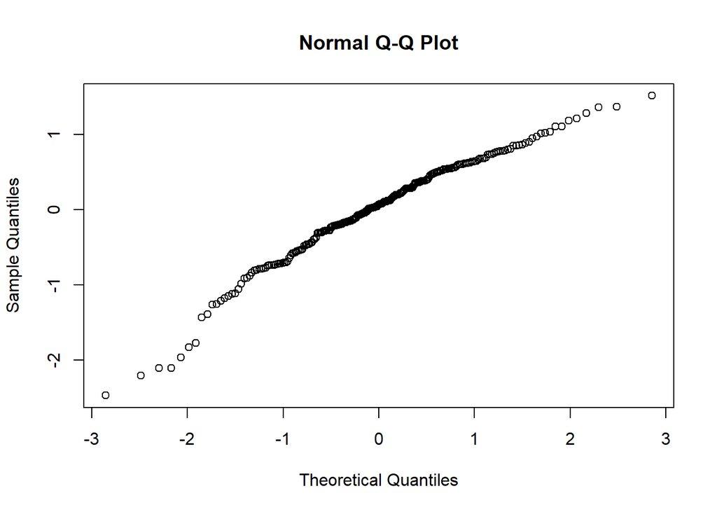

```r
qqnorm(residuals(pieceM))
```

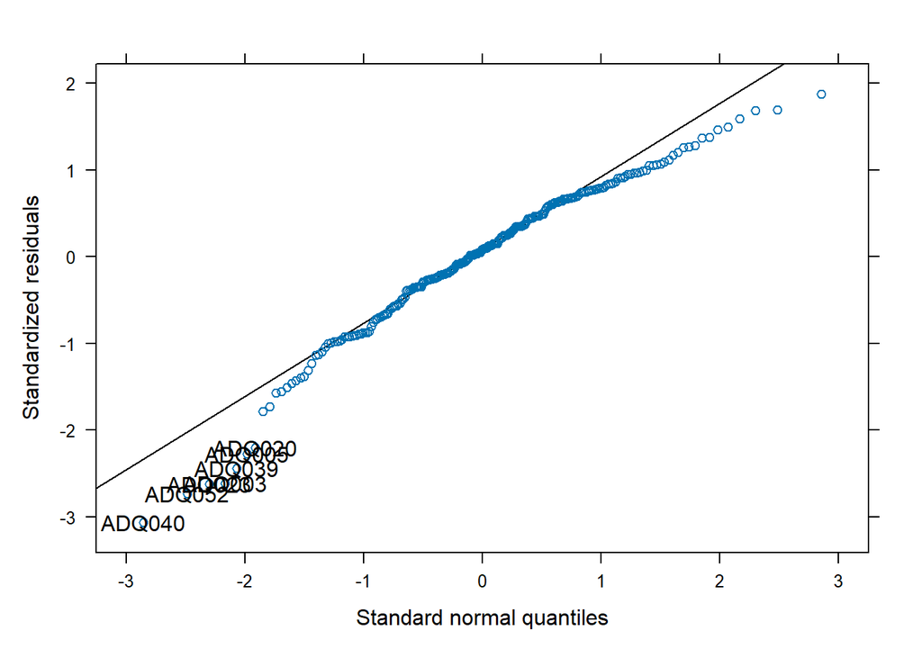

```r
require(lattice)
qqmath(pieceM, id=0.05) #id: identifies values that may be exerting undue influence on the model (i.e. outliers)
```

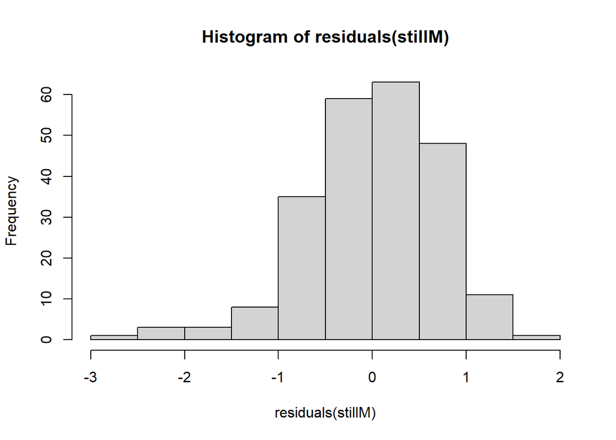

```r
# The histogram looks skewed with a negative tail.
hist(residuals(stillM)) # still looks skewed
```

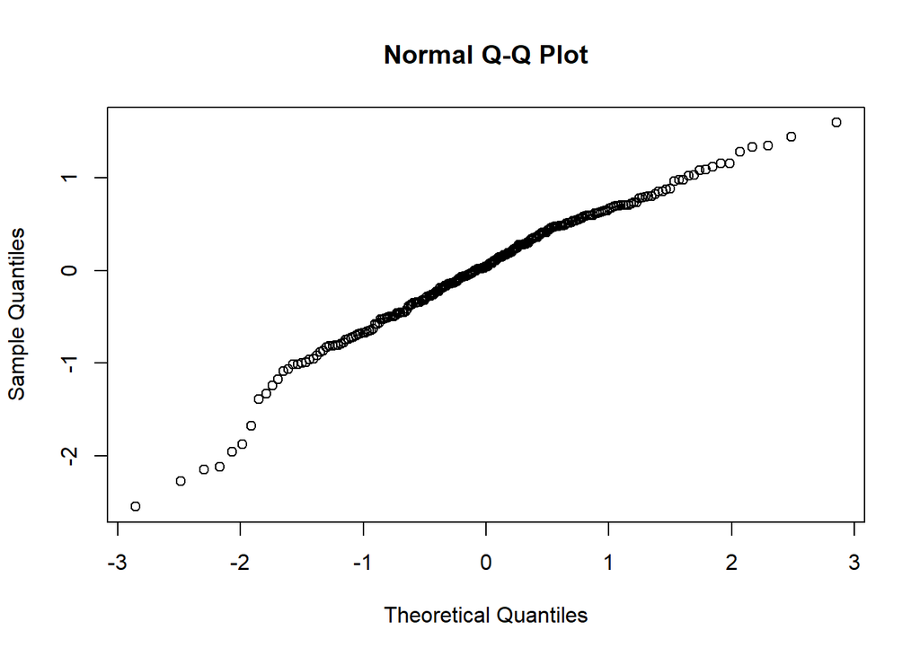

```r
qqnorm(residuals(stillM))
```

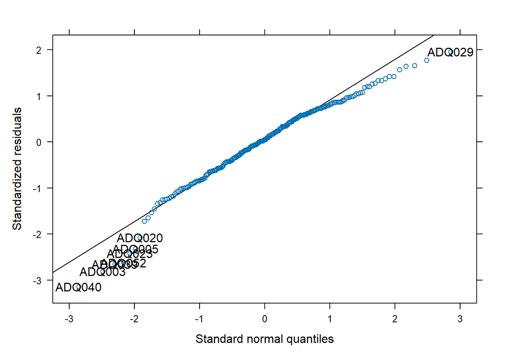

```r
qqmath(stillM, id=0.05) #id: identifies values that may be exerting undue influence on the model (i.e. outliers
```

#### Visualize

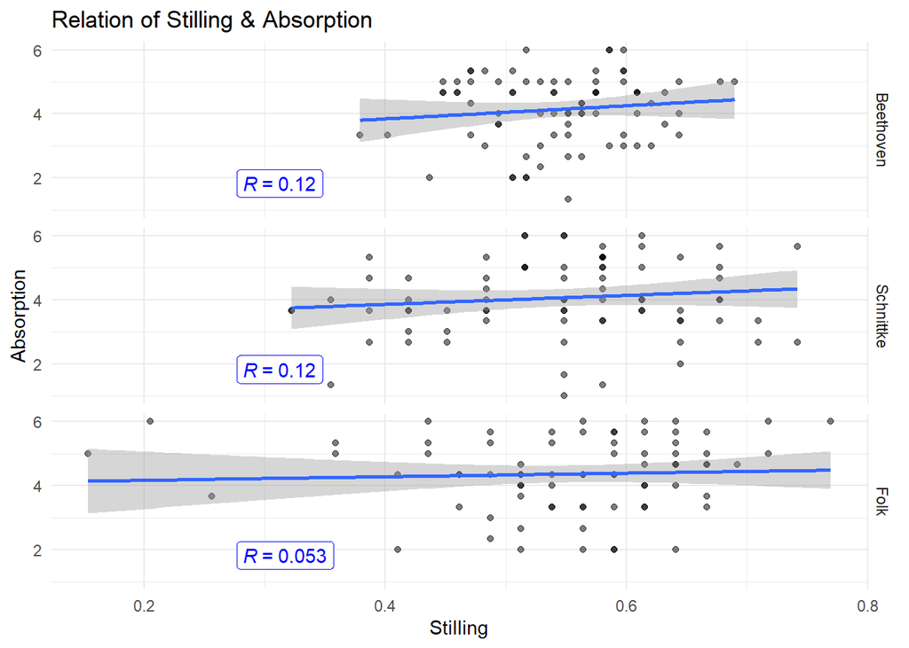

```r
title =  "Relation of Stilling & Absorption"
#subtitle= "No Extreme Outliers"

# r
p<-data%>%
  ggplot(aes(x = Stilling, y = Absorption))+
  geom_point(alpha = .5)+
  labs(title =title,x = "Stilling", y = "Absorption")+
  geom_smooth(method = lm)+
  facet_grid(rows = vars(piece))+
  theme_minimal()+
  stat_cor(aes(label = ..r.label..), label.x.npc = .2,label.y.npc = .2, color = "blue", geom = "label")#+
  #stat_cor(aes(label = ..rr.label..), label.x.npc = .65, color = "blue", geom = "label")+
  #stat_cor(aes(label = ..rr.label..), label.x.npc = .65, color = "blue", geom = "label")+
  #stat_cor(aes(label = ..r.label..), label.y.npc = .2,label.x.npc = .65, color = "blue", geom = "label")+
  #stat_cor(aes(label = paste(..rr.label.., ..p.label.., sep = "~`,`~")), label.x.npc = .6, color = "blue", geom = "label", size = 2.5)+
  #stat_cor(aes(label = ..r.label..), label.y.npc = .2,label.x.npc = .65, color = "blue", geom = "label", size = 2.5)

p
```

```r
graphname<-paste0("../revised_plots/", title, ".png")
ggsave(graphname, width = 15, height = 10, units = 'cm', dpi = 500)
graphname<-paste0("../revised_plots/Publication_Figures/", title, ".jpg")
ggsave(graphname, width = 15, height = 10, units = 'cm', dpi = 500, bg = "white")
```

## 3.6.3 Subjective experience of movement

5. What is the relation between absorption and perceived movement of self and others as well as quantified movement of self and other?

lme4 approach because missing data in some cells is preventing the mixed ANOVA method from working.

NOTE: the “perceived movement” responses were not continuous, but some were ordinal and some were categorical.Therefore, I should not use methods that rely on continuous data.

First, I can visualize the relation between absorption and awareness of motion to visually inspect for differences. If none are obvious, there might be no point in conducting a test anyways.

** Questions and Response Options **  
Q1: Were you aware of your physical body during this piece? Options: Not at all, Rarely, Intermittently, Continuously Q2: Were you aware of your own physical movement during this piece? If so, how much did you move relative to your own usual behaviour at this kind of concert? Options: Not aware of movement, Yes and I moved less than usual, Yes and I moved a normal amount, Yes and I moved more than usual Q3: Were you aware of others in the audience moving during the piece? If so, how much were they moving relative to the usual behaviour you observe at this kind of concert? Options: Not aware of others’ movement, Yes and they moved less than usual, Yes and they moved a normal amount, Yes and they moved more than usual

```r
movement_items<-c(
  "aware_body_Beethoven",
  "aware_movement_Beethoven",
  "aware_others_moving_Beethoven",
  "aware_body_Schnittke",
  "aware_movement_Schnittke",
  "aware_others_moving_Schnittke",
  "aware_body_Folk",
  "aware_movement_Folk",
  "aware_others_moving_Folk")

df_movement<-df.full%>%select("Pt_ID",group, contains(movement_items))

df_move.long<-df_movement%>%pivot_longer(!c(Pt_ID,group),
                        names_to = c("question", "piece"),
                        names_pattern ="(.*)_(.*)",
                        values_to = "response")

df_move.wide<-df_move.long%>%pivot_wider(names_from = question, values_from = response)
```

*Assign Types* factor, ordered factor, and numeric

```r
# aware body
ordering = c("Not at all","Rarely", "Intermittently", "Continuously")
## factor
df_move.wide$aware_body_f<-factor(df_move.wide$aware_body, levels = ordering)
## ordered factor
df_move.wide$aware_body_of<-factor(df_move.wide$aware_body, levels = ordering, ordered = TRUE)
## numeric
df_move.wide$aware_body_n<-as.numeric(df_move.wide$aware_body_f)

# aware movement
ordering =c("Not aware of movement","Yes and I moved less than usual", "Yes and I moved a normal amount", "Yes and I moved more than usual")
## factor
df_move.wide$aware_movement_f<- factor(df_move.wide$aware_movement, levels = ordering)
## ordered factor
df_move.wide$aware_movement_of<- factor(df_move.wide$aware_movement, levels = ordering, ordered = TRUE)
## numeric
df_move.wide$aware_movement_n<-as.numeric(df_move.wide$aware_movement_f)

# aware others movement
ordering =c("Not aware of others' movement", "Yes and they moved less than usual", "Yes and they moved a normal amount","Yes and they moved more than usual")
## factor
df_move.wide$aware_others_moving_f<- factor(df_move.wide$aware_others_moving, levels = ordering)
## ordered factor
df_move.wide$aware_others_moving_of<- factor(df_move.wide$aware_others_moving, levels = ordering, ordered = TRUE)
## numeric
df_move.wide$aware_others_moving_n<-as.numeric(df_move.wide$aware_others_moving_f)

describe(df_move.wide)
```

```
##                         vars   n  mean    sd median trimmed   mad min max range
## Pt_ID*                     1 408 68.50 39.31   68.5   68.50 50.41   1 136   135
## group*                     2 408  1.33  0.47    1.0    1.29  0.00   1   2     1
## piece*                     3 408  2.00  0.82    2.0    2.00  1.48   1   3     2
## aware_body*                4 374  2.73  0.77    3.0    2.74  0.00   1   4     3
## aware_movement*            5 373  6.60  0.96    7.0    6.63  1.48   5   8     3
## aware_others_moving*       6 365  9.72  1.10    9.0    9.53  0.00   9  12     3
## aware_body_f*              7 374  2.73  0.77    3.0    2.74  0.00   1   4     3
## aware_body_of*             8 374  2.73  0.77    3.0    2.74  0.00   1   4     3
## aware_body_n               9 374  2.73  0.77    3.0    2.74  0.00   1   4     3
## aware_movement_f*         10 373  2.60  0.96    3.0    2.63  1.48   1   4     3
## aware_movement_of*        11 373  2.60  0.96    3.0    2.63  1.48   1   4     3
## aware_movement_n          12 373  2.60  0.96    3.0    2.63  1.48   1   4     3
## aware_others_moving_f*    13 365  1.72  1.10    1.0    1.53  0.00   1   4     3
## aware_others_moving_of*   14 365  1.72  1.10    1.0    1.53  0.00   1   4     3
## aware_others_moving_n     15 365  1.72  1.10    1.0    1.53  0.00   1   4     3
##                          skew kurtosis   se
## Pt_ID*                   0.00    -1.21 1.95
## group*                   0.72    -1.49 0.02
## piece*                   0.00    -1.51 0.04
## aware_body*             -0.26    -0.26 0.04
## aware_movement*         -0.23    -0.88 0.05
## aware_others_moving*     1.15    -0.29 0.06
## aware_body_f*           -0.26    -0.26 0.04
## aware_body_of*          -0.26    -0.26 0.04
## aware_body_n            -0.26    -0.26 0.04
## aware_movement_f*       -0.23    -0.88 0.05
## aware_movement_of*      -0.23    -0.88 0.05
## aware_movement_n        -0.23    -0.88 0.05
## aware_others_moving_f*   1.15    -0.29 0.06
## aware_others_moving_of*  1.15    -0.29 0.06
## aware_others_moving_n    1.15    -0.29 0.06
```

```r
# combine with absorption
df_move_abs<-full_join(df_move.wide, musical_absorption.wide, by = c("Pt_ID", "piece"))
## factor order piece
df_move_abs$piece<-factor(df_move_abs$piece, levels = c("Beethoven", "Schnittke", "Folk"))

df_move_abs%<>%rename("Absorption" = "mus_abs")
```

### Visualize

#### Aware_body

ADQ062 has NAs from having missed two pages of the survey (the after beethoven movement awareness is missing)

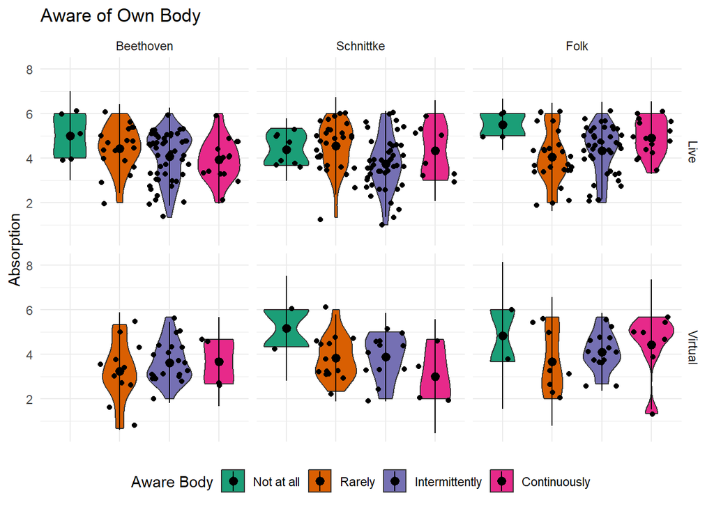

```r
df_move_abs%>%
  filter(! is.na(aware_body_f))%>%
  ggplot(aes(x= aware_body_f, y = Absorption, fill = aware_body_f))+
  geom_violin()+
  geom_jitter()+
  scale_fill_brewer(palette = "Dark2")+
  stat_summary(fun.data=mean_sdl, mult = 1,
               geom = "pointrange", color = "black")+
  facet_grid(cols = vars(piece), rows = vars(group))+
  theme_minimal()+
  theme(legend.position = "bottom")+
  theme(axis.text.x = element_blank())+
  theme(axis.title.x = element_blank())+
  labs(title = "Aware of Own Body", fill = "Aware Body")
```

#### Aware of own movement

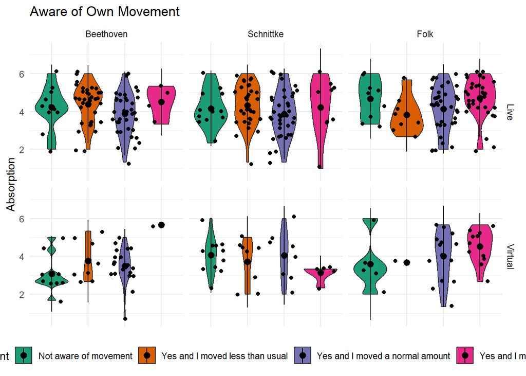

```r
df_move_abs%>%
  filter(! aware_movement_f==0)%>% filter(! is.na(aware_movement_f))%>%
  ggplot(aes(x= aware_movement_f, y = Absorption, fill = aware_movement_f))+
  geom_violin()+
  geom_jitter()+
  scale_fill_brewer(palette = "Dark2")+
  stat_summary(fun.data=mean_sdl, mult = 1,
               geom = "pointrange", color = "black")+
  facet_grid(cols = vars(piece),  rows = vars(group))+
  theme_minimal()+
  theme(legend.position = "bottom")+
  theme(axis.text.x = element_blank())+
  theme(axis.title.x = element_blank())+
  labs(title = "Aware of Own Movement", fill = "Aware Movement")
```

#### Aware of other’s movement

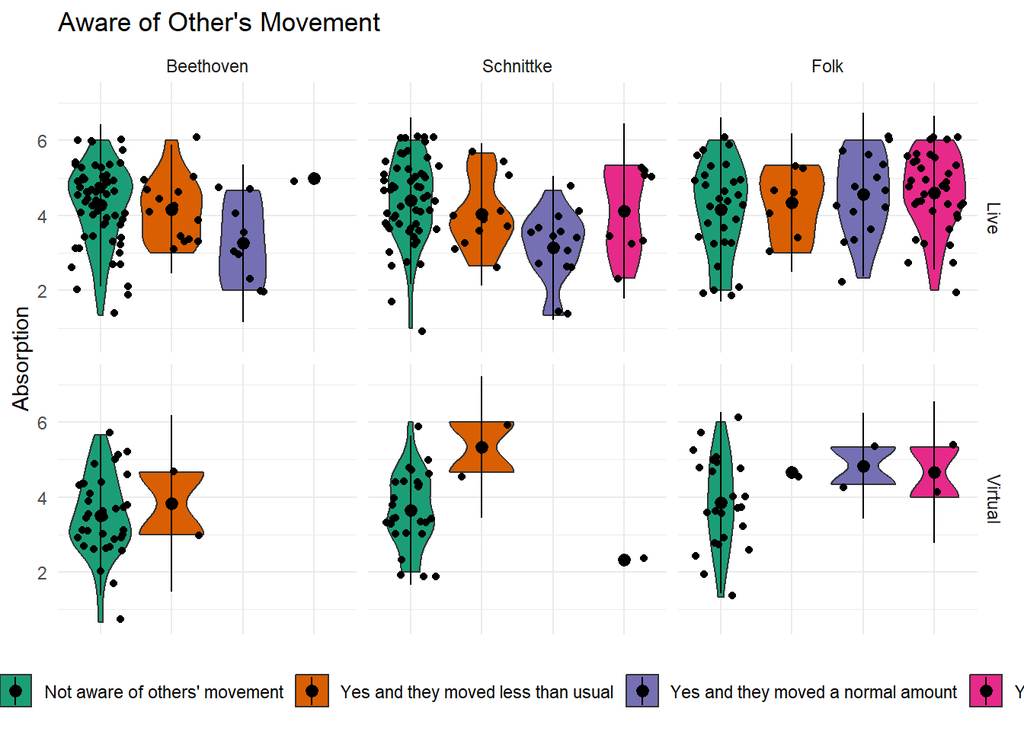

```r
df_move_abs%>%
  filter(! aware_others_moving_f==0)%>% filter(! is.na(aware_others_moving_f))%>%
  ggplot(aes(x= aware_others_moving_f, y = Absorption, fill = aware_others_moving_f))+
  geom_violin()+
  geom_jitter()+
  scale_fill_brewer(palette = "Dark2")+
  stat_summary(fun.data=mean_sdl, mult = 1,
               geom = "pointrange", color = "black")+
  facet_grid(cols = vars(piece), rows = vars(group))+
  theme_minimal()+
  theme(legend.position = "bottom")+
  theme(axis.text.x = element_blank())+
  theme(axis.title.x = element_blank())+
  labs(title = "Aware of Other's Movement", fill = "Aware Other's Movement")
```

### Test: Rmcorr

Finn suggests I could run a rank U test to examine whether there were differing absorption levels across different response options. There is a categorical distinction between not aware and aware.

Absorption and Awareness are repeated measures therefore a Mann-Whitney U test is actually not what we need.

Is there a relation between awareness and absorption? Repeated measures correlation with Spearman would be able to assess this. I don’t think that rmcorr can be changed to be used with Spearman but I can just try to see if there is an observed correlation

```r
# aware body: NS
rmc<-rmcorr(Pt_ID, aware_body_n,Absorption, df_move_abs)
rmc
```

```
##
## Repeated measures correlation
##
## r
## 0.01936514
##
## degrees of freedom
## 230
##
## p-value
## 0.76922
##
## 95% confidence interval
## -0.1097072 0.1477952
```

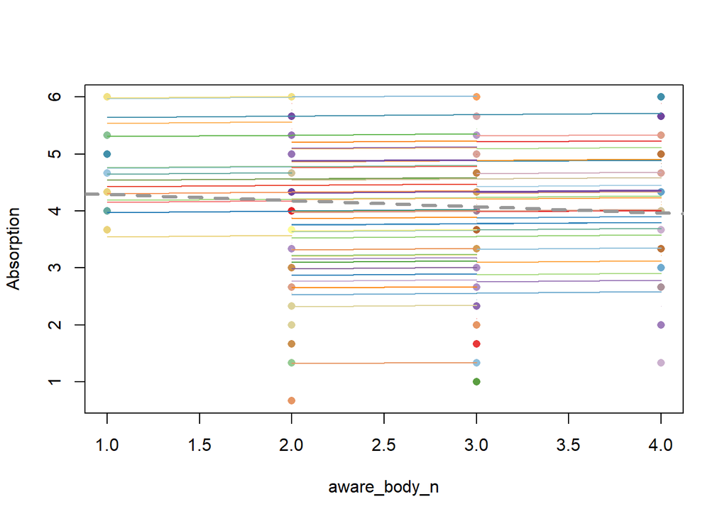

```r
plot(rmc, overall = TRUE)
```

```r
# aware movement: SIG
rmc<-rmcorr(Pt_ID, aware_movement_n,Absorption, df_move_abs)
rmc
```

```
##
## Repeated measures correlation
##
## r
## 0.1426222
##
## degrees of freedom
## 229
##
## p-value
## 0.03023486
##
## 95% confidence interval
## 0.0137985 0.2667884
```

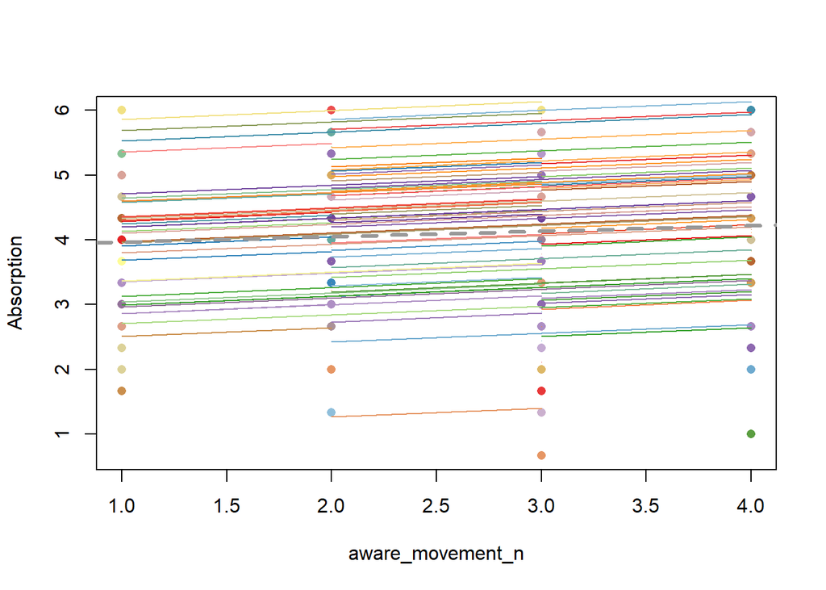

```r
plot(rmc, overall = TRUE)
```

```r
# aware others movement: SIG
rmc<-rmcorr(Pt_ID, aware_others_moving_n,Absorption, df_move_abs)
rmc
```

```
##
## Repeated measures correlation
##
## r
## 0.1625051
##
## degrees of freedom
## 223
##
## p-value
## 0.0146774
##
## 95% confidence interval
## 0.0324032 0.2871918
```

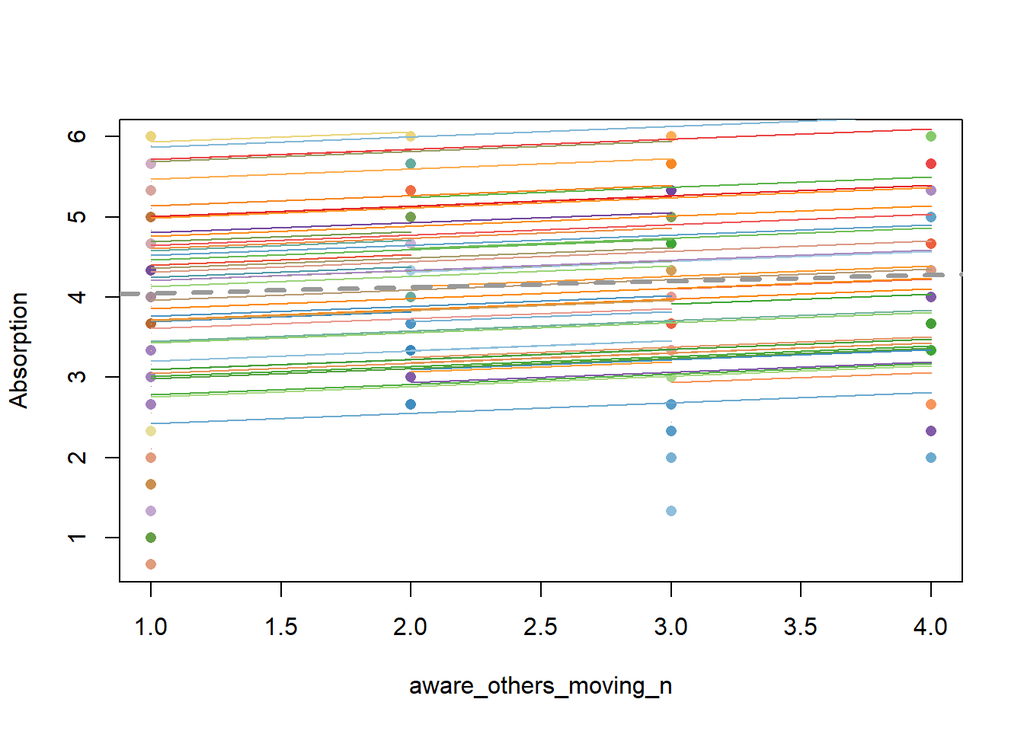

```r
plot(rmc, overall = TRUE)
```

### Test: LME

One resource suggests that for ordinal predictors in lme, you can either choose to treat it as a factor (categorical) or numeric (continuous). https://stats.stackexchange.com/questions/230802/including-ordinal-independent-variables-in-a-linear-mixed-effects-model-using-t

Here is a description of how to interpret output of R and lme based on the data type of the predictor variables: https://stackoverflow.com/questions/25735636/interpretation-of-ordered-and-non-ordered-factors-vs-numerical-predictors-in-m/25736023#25736023

Modelling the random effects structure appropriately is important. It could be modeled with a random intercept or a ranodm intercept and slope. The only way to model with a random slope is to treat the predictor variable as numeric.

Testing with mixed ANOVA is not possible because there are some design cells that are empty (cases where less than 3 people reported the same awareness level). Testing with ANCOVA does not allow for a repeated measures design. Including a random slope in addition to the random intercept may prevent the model from converging.

Is a random slope of participant necessary?

```r
aov.dat<-df_move_abs%>%
  filter(! is.na(aware_body))%>%
  filter(! is.na(aware_movement))%>%
  filter(! is.na(aware_others_moving))%>%
  drop_na()
```

#### Check assumptions

Aware Movement: 4 outliers, none extreme.

```r
check_assumptions_f<-aov.dat%>%select(Pt_ID, piece, group, aware_body_f, aware_movement_f, aware_others_moving_f,Absorption)
# Outliers
check_assumptions_f%>%group_by(piece, group)%>%identify_outliers(Absorption)
```

```
## # A tibble: 1 × 9
##   piece     group   Pt_ID  aware_body_f aware_movement_f   aware_others_moving_f
##   <fct>     <fct>   <chr>  <fct>        <fct>              <fct>
## 1 Beethoven Virtual BDQ092 Rarely       Yes and I moved a… Not aware of others'…
## # ℹ 3 more variables: Absorption <dbl>, is.outlier <lgl>, is.extreme <lgl>
```

```r
check_assumptions_f%>%group_by(piece, aware_body_f)%>%identify_outliers(Absorption)
```

```
## # A tibble: 2 × 9
##   piece     aware_body_f Pt_ID  group   aware_movement_f   aware_others_moving_f
##   <fct>     <fct>        <chr>  <fct>   <fct>              <fct>
## 1 Beethoven Rarely       BDQ092 Virtual Yes and I moved a… Not aware of others'…
## 2 Folk      Continuously BEQ098 Virtual Yes and I moved a… Not aware of others'…
## # ℹ 3 more variables: Absorption <dbl>, is.outlier <lgl>, is.extreme <lgl>
```

```r
check_assumptions_f%>%group_by(piece, aware_movement_f)%>%identify_outliers(Absorption)
```

```
## # A tibble: 4 × 9
##   piece aware_movement_f          Pt_ID group aware_body_f aware_others_moving_f
##   <fct> <fct>                     <chr> <fct> <fct>        <fct>
## 1 Folk  Yes and I moved less tha… ADQ0… Live  Intermitten… Not aware of others'…
## 2 Folk  Yes and I moved more tha… ADQ0… Live  Rarely       Yes and they moved m…
## 3 Folk  Yes and I moved more tha… ADR0… Live  Intermitten… Yes and they moved m…
## 4 Folk  Yes and I moved more tha… BEQ1… Virt… Rarely       Not aware of others'…
## # ℹ 3 more variables: Absorption <dbl>, is.outlier <lgl>, is.extreme <lgl>
```

```r
check_assumptions_f%>%group_by(piece, aware_others_moving_f)%>%identify_outliers(Absorption)
```

```
## # A tibble: 1 × 9
##   piece aware_others_moving_f          Pt_ID group aware_body_f aware_movement_f
##   <fct> <fct>                          <chr> <fct> <fct>        <fct>
## 1 Folk  Yes and they moved more than … ADQ0… Live  Rarely       Yes and I moved…
## # ℹ 3 more variables: Absorption <dbl>, is.outlier <lgl>, is.extreme <lgl>
```

```r
# Normality
aov.dat%>%group_by(piece, group)%>%shapiro_test(Absorption) # Normality assumption not met for any live piece
```

```
## # A tibble: 6 × 5
##   group   piece     variable   statistic        p
##   <fct>   <fct>     <chr>          <dbl>    <dbl>
## 1 Live    Beethoven Absorption     0.960 0.00872
## 2 Virtual Beethoven Absorption     0.964 0.277
## 3 Live    Schnittke Absorption     0.963 0.0121
## 4 Virtual Schnittke Absorption     0.947 0.156
## 5 Live    Folk      Absorption     0.944 0.000926
## 6 Virtual Folk      Absorption     0.970 0.551
```

```r
aov.dat%>%group_by(piece, aware_body_f)%>%shapiro_test(Absorption) # not met for several
```

```
## # A tibble: 12 × 5
##    piece     aware_body_f   variable   statistic       p
##    <fct>     <fct>          <chr>          <dbl>   <dbl>
##  1 Beethoven Not at all     Absorption     0.821 0.119
##  2 Beethoven Rarely         Absorption     0.958 0.293
##  3 Beethoven Intermittently Absorption     0.955 0.0141
##  4 Beethoven Continuously   Absorption     0.974 0.858
##  5 Schnittke Not at all     Absorption     0.916 0.322
##  6 Schnittke Rarely         Absorption     0.961 0.170
##  7 Schnittke Intermittently Absorption     0.982 0.583
##  8 Schnittke Continuously   Absorption     0.937 0.460
##  9 Folk      Not at all     Absorption     0.810 0.0718
## 10 Folk      Rarely         Absorption     0.943 0.0843
## 11 Folk      Intermittently Absorption     0.945 0.0124
## 12 Folk      Continuously   Absorption     0.866 0.00816
```

```r
aov.dat%>%group_by(piece, aware_movement_f)%>%shapiro_test(Absorption) # not met for several
```

```
## # A tibble: 12 × 5
##    piece     aware_movement_f                variable   statistic      p
##    <fct>     <fct>                           <chr>          <dbl>  <dbl>
##  1 Beethoven Not aware of movement           Absorption     0.957 0.516
##  2 Beethoven Yes and I moved less than usual Absorption     0.932 0.0141
##  3 Beethoven Yes and I moved a normal amount Absorption     0.975 0.290
##  4 Beethoven Yes and I moved more than usual Absorption     0.939 0.656
##  5 Schnittke Not aware of movement           Absorption     0.948 0.309
##  6 Schnittke Yes and I moved less than usual Absorption     0.962 0.215
##  7 Schnittke Yes and I moved a normal amount Absorption     0.971 0.338
##  8 Schnittke Yes and I moved more than usual Absorption     0.909 0.153
##  9 Folk      Not aware of movement           Absorption     0.922 0.235
## 10 Folk      Yes and I moved less than usual Absorption     0.936 0.536
## 11 Folk      Yes and I moved a normal amount Absorption     0.947 0.0281
## 12 Folk      Yes and I moved more than usual Absorption     0.933 0.0137
```

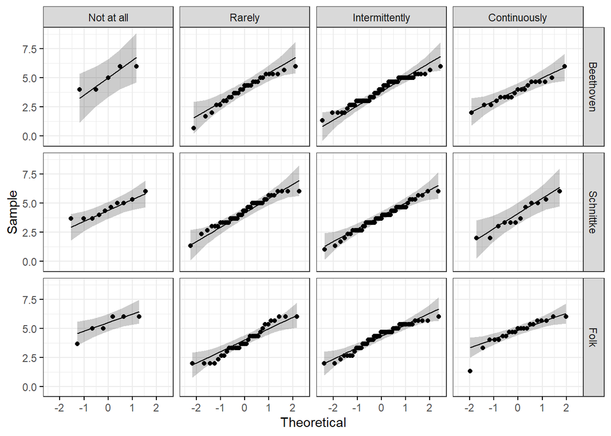

```r
#aov.dat%>%group_by(piece, aware_others_moving)%>%shapiro_test(Absorption) # One group has only one person therefore this test wouldn't run

# at high sample sizes normality is easily violated therefore a qqplot could be a better test
ggqqplot(aov.dat, "Absorption", ggtheme = theme_bw()) +
  facet_grid(piece ~ aware_body_f)
```

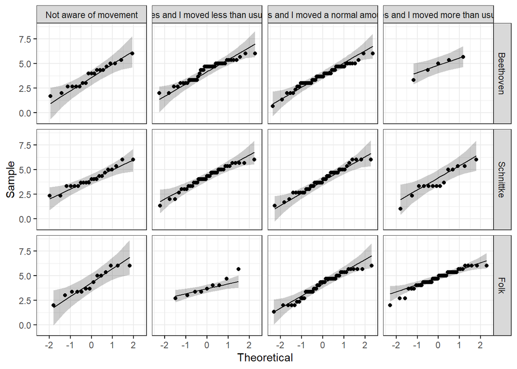

```r
ggqqplot(aov.dat, "Absorption", ggtheme = theme_bw()) +
  facet_grid(piece ~ aware_movement_f)
```

```
## `geom_line()`: Each group consists of only one observation.
## ℹ Do you need to adjust the group aesthetic?
```

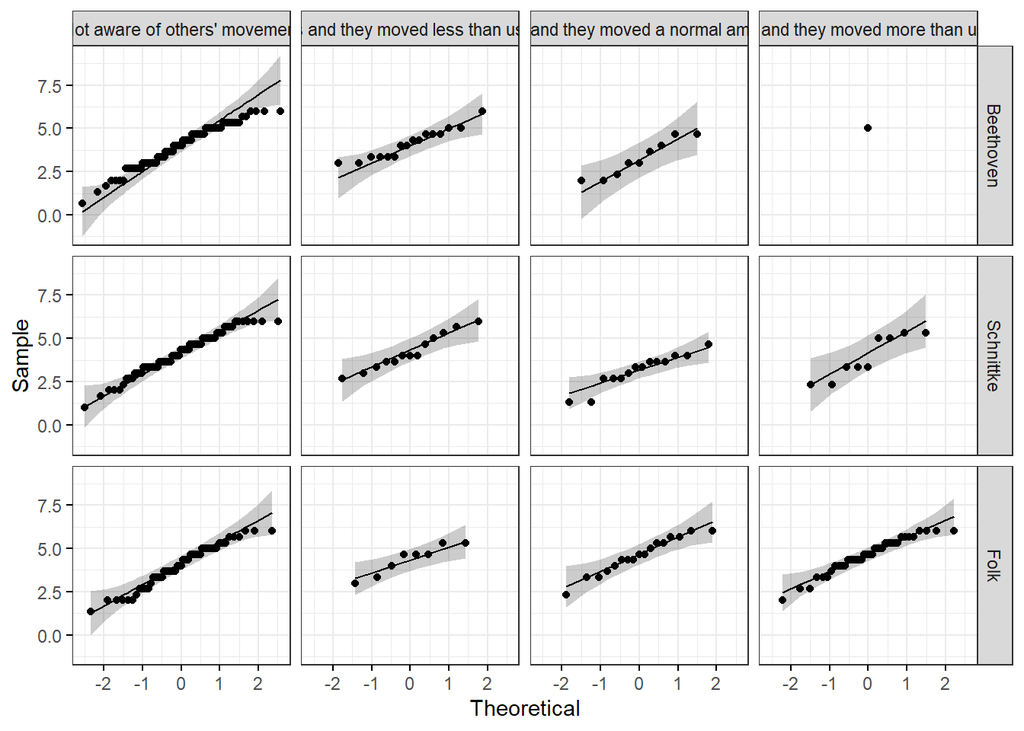

```r
ggqqplot(aov.dat, "Absorption", ggtheme = theme_bw()) +
  facet_grid(piece ~ aware_others_moving_f)
```

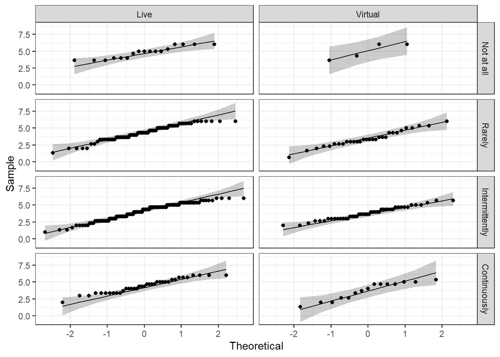

```r
ggqqplot(aov.dat, "Absorption", ggtheme = theme_bw()) +
  facet_grid(aware_body_f ~ group)
```

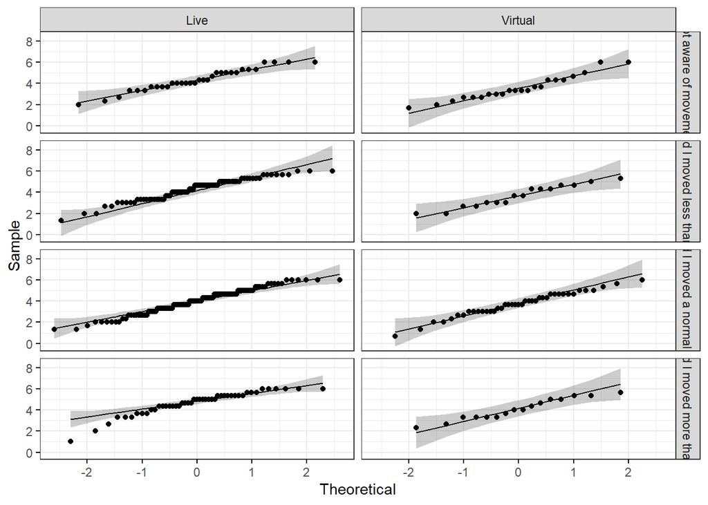

```r
ggqqplot(aov.dat, "Absorption", ggtheme = theme_bw()) +
  facet_grid(aware_movement_f ~ group)
```

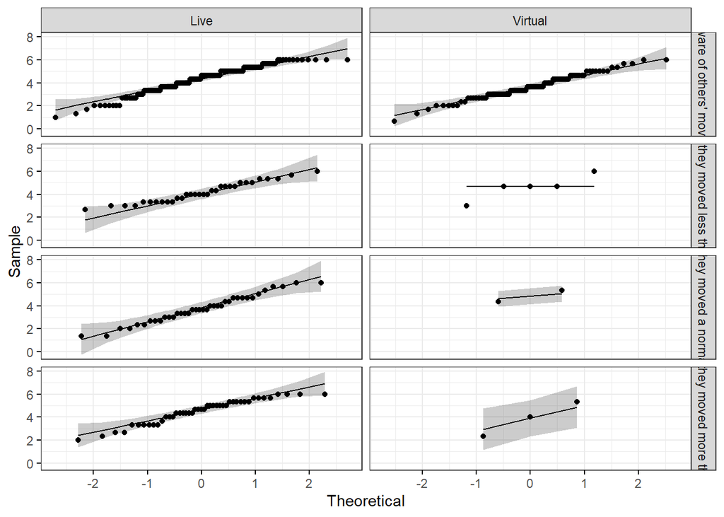

```r
ggqqplot(aov.dat, "Absorption", ggtheme = theme_bw()) +
  facet_grid(aware_others_moving_f ~ group)
```

```r
# some of these look really bad because there are very uneven samples between responses.

leveneTest(Absorption ~ group, data = aov.dat) # not violated.
```

```
## Levene's Test for Homogeneity of Variance (center = median)
##        Df F value Pr(>F)
## group   1  0.0066 0.9351
##       355
```